| title: “52414 - lab 2” |
| --- |
| author: “52414” |
| date: “25/5/2022” |
| output: html_document |

# *Lab 2: Text analysis, Sampling and inference*

## Analysis of textual data and the `Wordle` game

In this lab we will analyze textual data from the web. We will compute several statistics, and also implement and solve the popular game [wordle](https://en.wikipedia.org/wiki/Wordle).

### General Guidance

- Your solution should be submitted as a full `Rmd` report integrating text, code, figures and tables. You should also submit the `html` file generated from it. For each question, describe first in the text of your solution what you’re trying to do, then include the relevant code, then the results (e.g. figures/tables) and then a textual description of them.
- In most questions the extraction/manipulation of relevant parts of the data-frame can be performed using commands from the `tidyverse` and `dplyr` R packages, such as `head`, `arrange`, `aggregate`, `group-by`, `filter`, `select`, `summaries`, `mutate` etc.
- When displaying tables, show the relevant columns and rows with meaningful names, and describe the results.
- When displaying figures, make sure that the figure is clear to the reader, axis ranges are appropriate, labels for the axis , title and different curves/bars are displayed clearly (font sizes are large enough), a legend is shown when needed etc. Explain and describe in text what is shown in the figure.
- In many cases, data are missing (e.g. `NA`). Make sure that all your calculations (e.g. taking the maximum, average, correlation etc.) take this into account. Specifically, the calculations should ignore the missing values to allow us to compute the desired results for the rest of the values (for example, using the option `na.rm = TRUE`).
- **Grading:** There are $17$ questions overall (plus a *bonus* sub-question). Each *sub-question* is worth $6$ points. (Total: $102$ points)

### Questions:

#### PART 1 - MOBY-DICK

1.a. Load the complete `Moby dick` book from the [Gutenberg project](https://www.gutenberg.org) into `R`. The book is available [here](https://www.gutenberg.org/files/2701/2701-h/2701-h.htm). Extract the text from the html as a long string, and print the first line of the text in the file (starting with `The Project Gutenberg ...`)

```r
url <- 'https://www.gutenberg.org/files/2701/2701-h/2701-h.htm'
# Read the html into r:
html_str <- toString(html_text(read_html(url)))
as_string <- gsub("\r\n", " \n ", substr(html_str , 911, nchar(html_str)))
```

```r
unlist(strsplit(as_string, " \n "))[1] # extract the first line of the book.
```

```
## [1] "The Project Gutenberg eBook of Moby-Dick; or The Whale, by Herman Melville"
```

2. Split the text string into words, separated by spaces, commas (`,`), periods (`.`), and new line characters (`\n` and `\r`). How many words are there? Compute the distribution of lengths of words you got, and plot using a bar-plot. What are the `median`, `mean`, `longest` and `most common` word lengths?  
   **Note:** some of the “words” you will get will still contain non-English characters (e.g. numbers, `-`, `;` or other charactsers). Don’t worry about it. We will parse the words further later when needed.

```r
delete_not_char <- function(a, b=F){ # this function designed to delete all the non charter characters from the book.
  a <- str_replace_all(a,"[ \n ]", " ")
  a <- str_replace_all(a,"[^a-zA-Z ]", "") # refer to shortcut like "can't" to cant.
  if (b==T){a <- str_to_lower(a)}
  a
}

split_a <- function(a, b=F){ # a function that get function that gets string and give list of words.
  a <- delete_not_char(a, b)
  a <- unlist(strsplit(a, " ")[1])
 return(a[a!=""])
}

words <- split_a(as_string) # apply function on strings to vector of words.
len_words <- nchar(words) # creates a new vector with the length of each word.
longest_words <- words[which.max(len_words)]
median_words <- median(len_words)
mean_words <- mean(len_words)
t_len_words <- table(len_words)
most_common <- names(t_len_words[order(t_len_words, decreasing = T)][1])
```

longest words: `swayingscoyingsflutterings`

median words: `4`

mean words: `4.505027`

most common: `3`

3. Count the words frequencies in the text - i.e. the number of times each unique word appears in the text. Show the top 10 most frequent words with their frequencies. Is the list of top words surprising? explain.

```r
t_words <- table(words)
t_words[order(t_words, decreasing = T)][1:10]
```

```
## words
##   the    of   and    to     a    in  that   his    it     I
## 13887  6675  6076  4591  4556  3977  2890  2464  2104  1943
```

not that surprising, really common-daily words.

2.a. Split the book text into `chapters`, such that you obtain an array of strings, one per chapter. Count and plot the number of words per each chapter (y-axis) vs. the chapter index (1,2,3.., on x-axis). (each chapter is splitted to word in the same manner as in Qu. 1).  
**Hint:** Chapters begin with the string `CHAPTER` followed by a space and then the chapter’s number and a period. For example: `CHAPTER 2.` is at the start of chapter 2. But beware - this pattern by itself is not enough to identify correctly all chapters starts and end. You will need to *look at the text* in order to decide what patterns to look for when splitting the data into chapters.

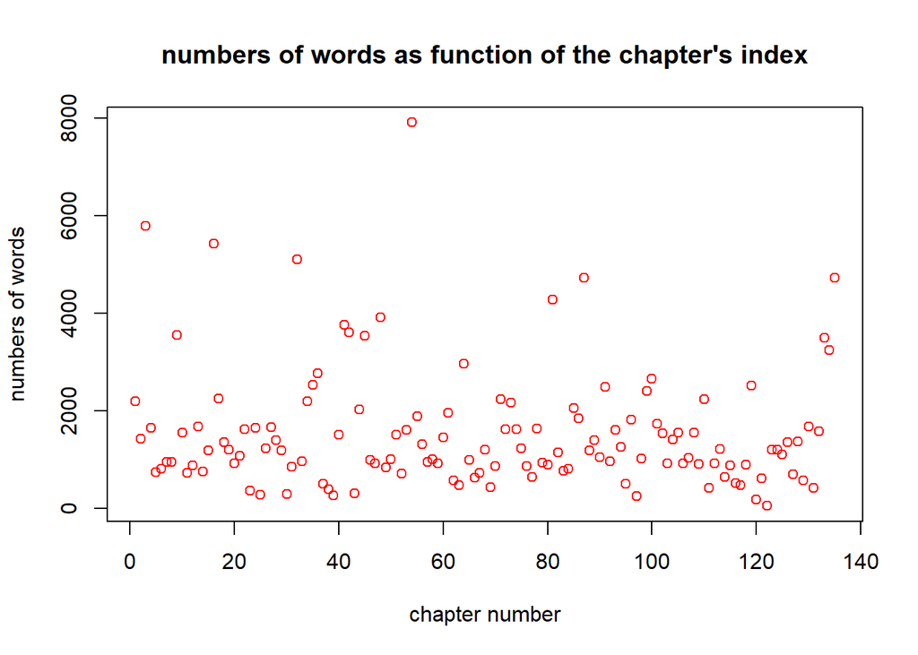

```r
begining <- str_locate_all( as_string,"CHAPTER 1. Loomings")[[1]][2,1]
end <- str_locate_all( as_string,"only found another orphan.")[[1]][1,2]
book <- str_sub(as_string, begining, end) # triming the book from start to end.
book <- delete_not_char (book) # include CHAPTER name
by_chepter <- str_split(book, "      CHAPTER  ")[[1]]
n_chepter <- length(by_chepter)
word_n_by_chepter <- rep(0,n_chepter)
for (i in 1:n_chepter){
  word_n_by_chepter[i] <- length(split_a(by_chepter[i]))
}
word_n_by_chepter[1] <- word_n_by_chepter[1] - 1 # without the word "CHAPTER".
index <- 1:length(word_n_by_chepter)
plot(index,word_n_by_chepter, col = "red",main = "numbers of words as function of the chapter's index", xlab = "chapter number",ylab = "numbers of words")
```

2. Write a function that receives as input a query word, and an array of strings representing the chapters. The function returns a vector of the `relative frequencies` of the word in each chapter. That is, if for example the word `time` appears six times in the first chapter, and there are overall $3247$ words in this chapter, then the first entry in the output vector of the function will be $6/3247 \approx 0.0018$.  
   Apply the function to the following words `Ahab`, `Moby`, `sea`. Plot for each one of them the trend, i.e. the frequency vs. chapter, with chapters in increasing orders. Do you see a different behavior for the different words? in which parts of the book are they frequent?

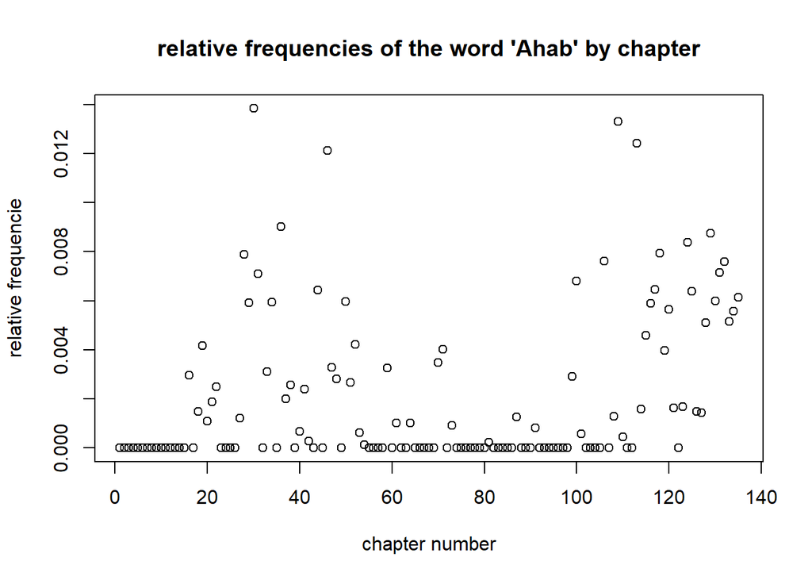

```r
get_frq <- function(string_word, by_chepter){ # create a function that yields relative frequencies.
    output <- rep(0,length(by_chepter))
    for (i in 1:length(by_chepter)){
      a <- table( split_a(by_chepter[i]) )
      if (string_word %in% names(a)){
        output[i] <- as.numeric(a[names(a) == string_word]) / word_n_by_chepter[i]
        }
    }
output
}
plot(index,get_frq('Ahab',by_chepter),main = "relative frequencies of the word 'Ahab' by chapter", xlab = "chapter number",ylab = "relative frequencie")
```

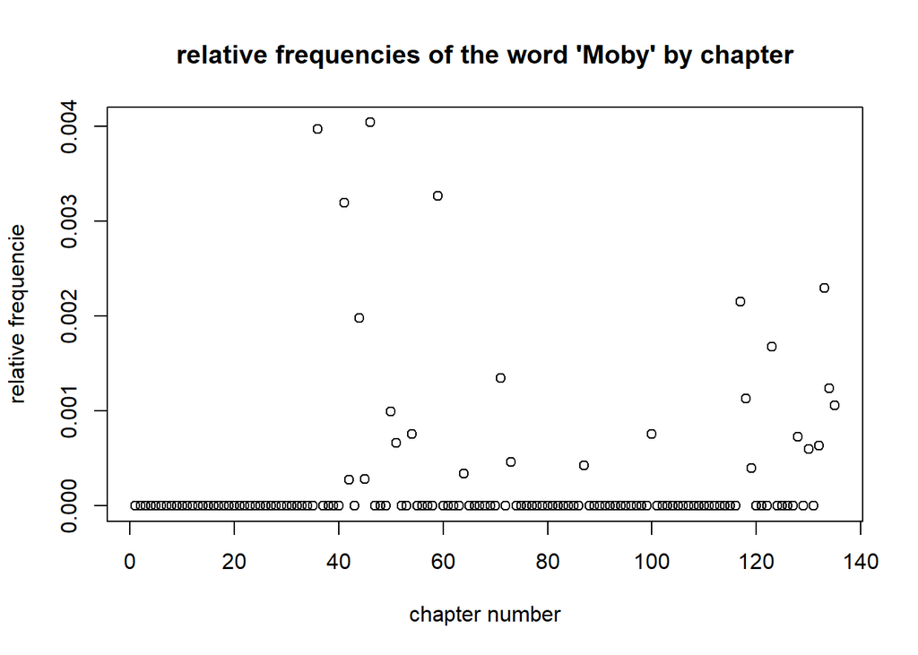

```r
plot(index,get_frq('Moby',by_chepter),main = "relative frequencies of the word 'Moby' by chapter", xlab = "chapter number",ylab = "relative frequencie")
```

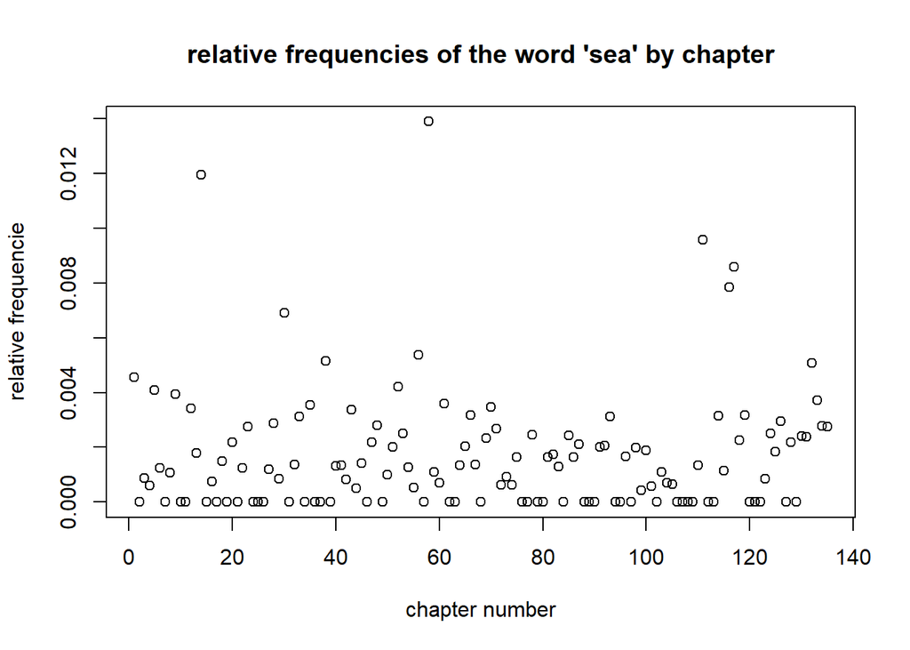

```r
plot(index,get_frq('sea',by_chepter),main = "relative frequencies of the word 'sea' by chapter", xlab = "chapter number",ylab = "relative frequencie")
```

we can observe that the words who describe characters has an unstable frequency (probably because the specific way of evolving plot), in compare of the word “sea” which is a meant to describe landscape.

3.a. Suppose that Alice and Bob each choose independently and uniformly at random a single word from the book. That is, each of them chooses a random word instance from the book, taking into account that words have different frequencies (i.e. if for example the word `the` appears $1000$ times, and the word `Ishmael` appears only once, then it is $1000$-times more likely to choose the word `the` because each of its instances can be chosen). What is the probability that they will pick the same word? Answer in two ways:  
(i) Derive an exact formula for this probability as a function of the words relative frequencies, and compute the resulting value for the word frequencies you got for the book.

$P(get\ one\ word\ i) = \frac{x_{i}}{\sum{x_{i}}}$ $P(get\ same\ word\ i) = (\frac{x_{i}}{\sum_{j}{x_{j}}})^2$ $P(get\ same\ word) = \sum_{i}{ P(get\ one\ word\ i)}^2 = \sum_{i}{ (\frac{x_{i}}{\sum_{j}{x_{j}}})^2} = \frac{\sum_{i}{(x_{i}})^2}{(\sum_{j}{x_{j}})^2 }$

```r
sum(t_words^2)/(sum((t_words))^2) # apply of the formula above
```

```
## [1] 0.008768721
```

2. Simulate $B=100,000$ times the choice of Alice and Bob and use these simulations to estimate the probability that they chose the same word.  
   Explain your calculations in both ways and compare the results. Are they close to each other?

```r
# by monta-carlo method we sample n samples and check the percent of the equal samples.
book_vector <- split_a(book)
n_words <- length(book_vector)
indicator <- 0
a <- sample(1:n_words, size = 100000)
b <- sample(1:n_words, size = 100000)
c <- as.numeric(book_vector[a] == book_vector[b])
sum(c) / 100000
```

```
## [1] 0.00877
```

almost the same!

2. Suppose that instead, we took all **unique** words that appear in the book, and then Alice and Bob would choose each independently and uniformly at random a single word from the list of unique words. What would be the probability that they chose the same word in this case? is it lower, the same, or higher then the probability in (a.)? explain why.

```r
t_words <- table(book_vector ) # using table to extract all the unique words.
not_unique <- 1 / length(t_words)
# in the formula we sample one word out of n word twice and then sum that probability over all the n words which give us a 1/n probability.
```

not unique, when all word is value 1, 4.7614513^{-5}, is lower

only by knowing first sum of ratio:

```r
o_t_words <- order(t_words, decreasing = T)
sum((o_t_words[1:3]/length(t_words))^2)
```

```
## [1] 1.104841
```

4.a. Extract from the book a list of all `five-letter` words. Keep only words that have only English letters. Convert all to lower-case. How many words are you left with? how many unique words? Show the top 10 most frequent five-letter words with their frequencies.

```r
book_vector_b <- split_a(book, b=T)
only_5 <- book_vector_b[nchar(book_vector_b)==5]
t_words_b <- table(only_5)
o_t_b_words <- t_words_b[order(t_words_b, decreasing = T)][1:10]
output_all <- length(t_words_b)
output_5 <- length(only_5)
o_t_b_words # the most frequented 5 letters words.
```

```
## only_5
## whale there which their would other these still about those
##   890   754   617   603   421   393   387   307   305   302
```

as we can see in the output there is 24750 words out of 2031.

2. Compute letter frequencies statistics of the five-letter words: That is, for each of the five locations in the word (first, second,..), how many times each of the English letters `a`, `b`,…,`z` appeared in your (non-unique) list of words. Store the result in a `26-by-5` table and show it as a heatmap. Which letter is most common in each location? Do you see a strong effect for the location?

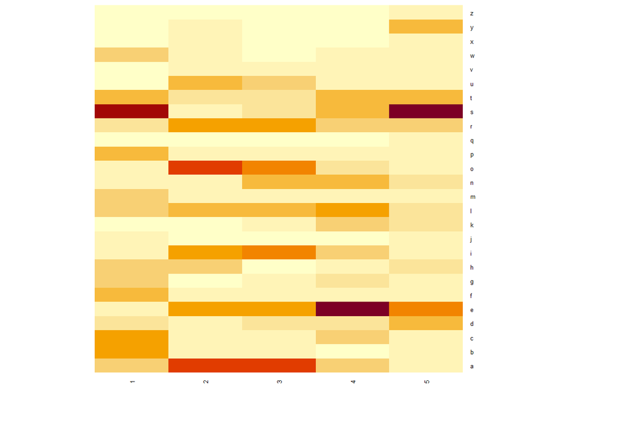

```r
words_5b <- names(t_words_b)
b4 <- function(words_5letters, heat = T){ # this function is meant to create a matrix of frequency of letters locations in the words of the book.
out_met <- matrix(data = rep(0, 26*5), nrow = 26, ncol = 5)
for (i in 1:26){
  for (j in words_5letters){
    a = str_locate_all (j , letters[i])[[1]][,1]
  out_met[i, a] = out_met[i,a] + 1
  }
}
rownames(out_met) <- letters
if(heat){ # if heat map is wanted, return heatmap.
out_heat <- heatmap(out_met,  Colv = NA, Rowv = NA,cexRow = 0.5,cexCol = 0.5, scale="column")
return(list(out_met,out_heat))}
return(out_met)
}
b4_a <- b4(words_5b)
```

```r
five_matrix <- b4_a[[1]]
output_s <- which(five_matrix==max(five_matrix),arr.ind=T)
output_s
```

```
##   row col
## s  19   5
```

the letter with the highest appearances is ‘s’ in the ‘5’ place in word. we can see that for certain letters there is a storng effect of the place in the word. we should expect that effect because it makes sense from the language prepective: for example, we know that the letter s in the last place in a word is used in english to show plural.

3. Consider the following random model for typing words: we have a `26-by-5` table of probabilities $p_{ij}$ for i from $1$ to $5$, and $j$ going over all $26$ possible English letters (assuming lower-case). (This table stores the parameters of the model). Here, $p_{ij}$ is the probability that the $i$-th letter in the word will be the character $j$. Now, each letter $i$ is typed from a categorical distribution over the $26$ letters, with probability $p_{ij}$ of being the character $j$, and the letters are drawn independently for different values of $i$. For example, using $p_{5s}=0.3$ we will draw words such that the probability of the last character being `s` will be $0.3$.  
   For each five-letter word $w$, its likelihood under this model is defined simply as the probability of observing this word when drawing a word according to this model, that is, if $w=(w_1,w_2,w_3,w_4,w_5)$ with $w_i$ denoting the $i$-th letter, then $Like(w ; p) = \prod_{i=1}^5 p_{i w_i}$.  
   Write a function that receives a `26-by-5` table of probabilities and an array of words (strings), and computes the likelihood of each word according to this model.  
   Run the function to compute the likelihood of all unique five-letter words from the book, with the frequency table you computed in 4.b. normalized to probabilities. Show the top-10 words with the highest likelihood.

```r
table_prob_a <- function(tble){ # takes frequencies table to column-probebility table
  weight <- (sum(tble[,1])) ^ (-1) # the 1/sum of each coulmn.
  return(tble*weight)
}

table_prob_b <- function(tble, arr){ # takes probablity table and word array return likelyhood of each word
  g <- rep(0,length(arr))
  for (j in 1:length(g)){
    a = 1
    word_a <- strsplit(arr[j],'')[[1]]
  for (i in 1:length(word_a)){
    a <- a * tble[c(word_a[i]),i]
  }
  g[j] <- a
  }
  return(arr[order(g, decreasing = T)])
}


table_prob <- function(tble, arr){ #united
  return(table_prob_b(table_prob_a(tble),arr))
         }

table_prob(five_matrix,names(t_words_b))[1:10]
```

```
##  [1] "soles" "sires" "sails" "cares" "soils" "canes" "soars" "cones" "shoes"
## [10] "seals"
```

because we considered for each word “word”, possessive “word’s” and plural “words”, as single words, s at the end was very common.

#### PART 2 - WORDLE

In `wordle`, the goal is to guess an unknown five-letter English word. At each turn, we guess a word, and get the following feedback: the locations at which our guess matches the unknown word (`correct`), the locations at which our guess has a letter that appears in the unknown word but in a different location (`wrong`), and the locations at which our guess contains a letter that is not present in the unknown word (`miss`).

We supply to you a function called `wordle_match`, that receives as input a guess word and the true word (two strings), and returns an array of the same length indicating if there was a `correct` match (1), a match in the `wrong` location (-1), or a `miss` (0). For example: calling `match_words("honey", "bunny")` will yield the array: `[0, 0, 1, 0, 1]`, whereas calling `match_words("maple", "syrup")` will yield the array `[0, 0, -1, 0, 0]`.

**Note:** It is allowed for both the unknown word and the guess word to contain the same letter twice or more. In that case, we treat each letter in the guess as a `wrong` match if the same letter appears elsewhere in the unknown word. This is a bit different from the rules of the `wordle` game and is used for simplification here.

```r
# Helper function:
match_words <- function(guess, word)  # 1: correct location, -1: wrong location, 0: missing
{
  L <- nchar(guess)
  match <- rep(0, L)
  for(i in 1:L)
  {
    if(grepl(substr(guess, i, i), word, fixed=TRUE))
      {match[i] = -1}
    if(substr(guess, i, i) == substr(word, i, i))
    {      match[i] = 1}
  }

  return(match)
}

match_words("maple", "syrup")
```

```
## [1]  0  0 -1  0  0
```

5.a. Download the list of five-letter words from [here](https://www-cs-faculty.stanford.edu/~knuth/sgb-words.txt). This list contains most common English five-letter words (each word appears once).  
Compute and display the `26-by-5` table of frequencies for this word list, in similar to Qu. 4.b. Do you see major differences between the two tables? why?

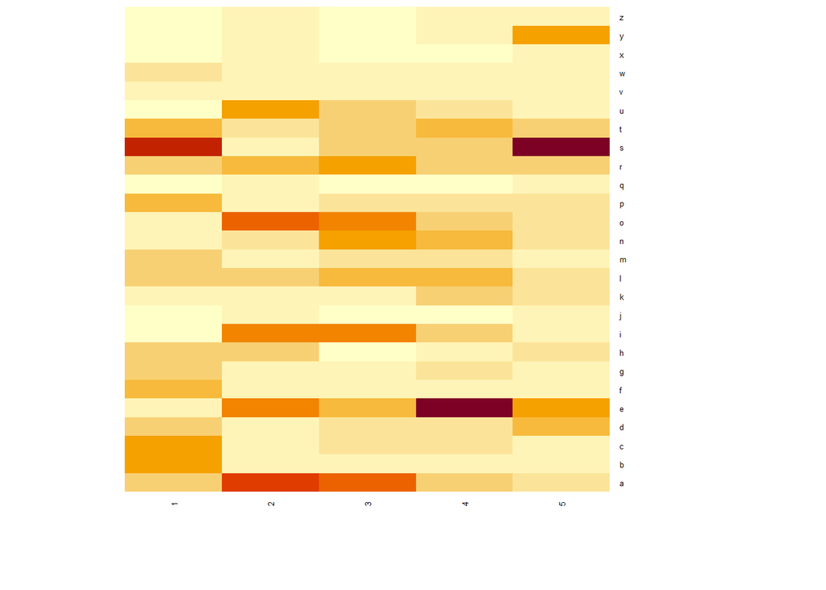

```
## [[1]]
##   [,1] [,2] [,3] [,4] [,5]
## a  296  930  605  339  178
## b  432   32  128   99   24
## c  440   82  184  210   48
## d  311   43  178  218  431
## e  129  660  397 1228  595
## f  318   12   87  100   44
## g  279   24  139  176   61
## h  239  271   39   73  192
## i   74  673  516  284   45
## j   73    4    8    4    0
## k   91   29   90  243  143
## l  271  360  388  365  202
## m  298   71  209  188   77
## n  118  168  410  386  203
## o  108  911  484  262  150
## p  386  113  169  196   91
## q   39   10    4    0    0
## r  268  456  475  310  401
## s  724   40  248  257 1764
## t  376  122  280  447  360
## u   75  534  313  154   13
## v  109   27  121   61    0
## w  228   81   98   70   28
## x    4   33   67    5   30
## y   47   65   68   41  665
## z   24    6   52   41   12
##
## [[2]]
## [[2]]$rowInd
##  [1]  1  2  3  4  5  6  7  8  9 10 11 12 13 14 15 16 17 18 19 20 21 22 23 24 25
## [26] 26
##
## [[2]]$colInd
## [1] 1 2 3 4 5
##
## [[2]]$Rowv
## NULL
##
## [[2]]$Colv
## NULL
```

```r
wordling <- paste(readLines("C:/Users/eldad/Downloads/sgb-words.txt"))
b4(wordling)
```

we do not see a major diffrences between the tables. that because the most common letters are the one that corralated with english language as explained before fo the letter ‘s’.

2. Write a function that receives an array of guess words, an array of their corresponding matches to the unknown word (i.e. a two-dimensional array), and a `disctionary` - i.e. an array of legal English words. The function should return all the words in the dictionary that are consistent with the results of the previous guesses. For example, if we guessed `maple` and our match was the array `[1, 0, -1, 0, 0]`, then we should keep only words that start with an `m`, have a `p` at a location different from $3$, and don’t have `a`, `l` and `e`. When we have multiple guesses, our list of consistent words should be consistent with all of them, hence as we add more guesses, the list of consistent words will become shorter and shorter.  
   Run your function on the list of words from (a.), and with the guesses `c("south", "north")` and their corresponding matches: `c(-1, 1, 1, 0, 0)` and `c(0, 1, 0, 0, 0)`. Output the list of consistent words with these two guesses.

```r
b5 <- function(array_guess , array_matches, disctionary){
    # takes array of guess results and responds and detcet possible words in a certain dictionary
  certain <- rep('.', 5) # must be in the place.
  nothing <- c() # not in any place.
  certain_not <- rep('.',5) # not in specific place.
  total <- c() # all possible words
  for (i in 1:5){ # add to the vectors the data from the guess's results.
    col = array_matches[,i]
    w <- which(0 == col)
    if (length(w) != 0){
      nothing <- unique(append(nothing, str_sub(array_guess[w],i,i)))}
    w <- which(-1 == col)
    if (length(w) != 0){
      total <- unique(append(total, str_sub(array_guess[w],i,i)))}
    if (1 %in% col) {
      certain[i] <- str_sub(array_guess[which(1 == col)[1]],i,i)}
    else if (length(w) != 0){
      certain_not[i] <- paste('[^(',paste(unique(str_sub(array_guess[w],i,i)),collapse = '|'),')]')}
  }

  correct = sum(as.numeric(certain != '.')) # check how much certain letters
  output <- c()
  for (i in c(1:5)[certain == '.']){ # paste to regex
    if (certain_not[i] != '.'){certain[i] <- certain_not[i]}}

  certain <- paste(certain, collapse = '' )
    if (correct == 5){return(certain)} # if 5 certain letters it's correct

  if (length (total) != 0){
    total = total[!total %in% certain[certain != '.']]
    total_n = length(total)} # all letters that are in word, and missed


  if (length(nothing)!=0)
    {for (i in disctionary ) { # if in the conditions add output
      if (length(str_which( i ,nothing)) == 0){ output <- append(output, i)}
    }} # compare to see if a certain words can match the result we have.
  else
  {output<- disctionary}
  output <- output[str_detect(output,certain)] # if in the regex conditions delet from output
  if (length (total) != 0){
  for (i in output){
    if(length(str_which(i,total)) < total_n){ output <-output[output!=i]} # chack if all misses letters are in each word in output
  }
  }
  return(output)
}
a_g = c("south", "north")
a_m = matrix(c(-1, 1, 1, 0, 0, 0, 1, 0, 0, 0),nrow = 2,byrow = T)
b5(a_g,a_m,wordling)
```

```
##  [1] "mouse" "lousy" "louse" "fouls" "douse" "louis" "coups" "mousy" "poufs"
## [10] "youse"
```

6.a. Consider the following (rather naive) guessing strategy, called **strategy 1:**  
- We start with a random word with each letter sampled uniformly and independently from the $26$ English letters. - Then, at each turn, we look only at the previous perfect matches (`correct`) to the target word, and ignore matches at the `wrong` location and missing letters. At each place where there is a correct match, we use the correct letter, and at all other locations we keep sampling uniformly from the $26$ letters. We keep going until we get all the five letters correctly (and hence the word).

We are interested in the number of turns (guesses) needed until we get the correct word.

Implement a function that receives as input the unknown word, and implements this strategy. The output should be the number of turns it took to guess the word. The function should also record and print guess at each turn, as well as the match array , until the word is guessed correctly.  
Run the function when the unknown word is “mouse”, and show the results.

```r
a6 <- function(word_true, p = T){ # this function designed to implement the strategy above. the function has a printing argument p.
  guess <- sample(letters, 5, replace = T) # sample letters (uniform distribution) to form a guess.
  guess <- paste(guess, collapse = "")
  response <- match_words(word_true, guess)
  times <- 1
  guesses <- c(guess)
  while(!all(response == c(1,1,1,1,1))) { # keep the process until perfect match.
    guess <- strsplit(guess,'')[[1]]
    guess[response != 1] <- sample(letters, length(guess[response != 1]), replace = T)
    guess <- paste(guess, collapse = "")
    response <- match_words(word_true, guess)
    guesses <- append(guesses, guess)
    times <- times + 1
  }
  output <- list(times, guesses)
  if(p == T){
  print(output)} else {
  return(output) }
}
a6('mouse')
```

```
## [[1]]
## [1] 79
##
## [[2]]
##  [1] "yltiy" "uylid" "vffpr" "fybgp" "dshzr" "hqxxw" "vpjoq" "nmluo" "vkoyh"
## [10] "oaivg" "iviqb" "haypv" "bxtcr" "spact" "tfoje" "khzxe" "vynve" "ywyne"
## [19] "biwve" "jgwne" "lsgre" "aglme" "tzwee" "ryuse" "sluse" "kluse" "ctuse"
## [28] "gouse" "kouse" "qouse" "jouse" "eouse" "louse" "qouse" "wouse" "uouse"
## [37] "couse" "aouse" "xouse" "nouse" "kouse" "youse" "oouse" "louse" "zouse"
## [46] "couse" "louse" "douse" "louse" "youse" "kouse" "kouse" "touse" "vouse"
## [55] "bouse" "uouse" "jouse" "house" "jouse" "douse" "youse" "rouse" "nouse"
## [64] "qouse" "eouse" "fouse" "bouse" "youse" "iouse" "iouse" "jouse" "aouse"
## [73] "pouse" "douse" "fouse" "xouse" "zouse" "uouse" "mouse"
```

2. Write a mathematical formula for the distribution of the number of turns needed to guess the target word with this strategy.  
   **Hint:** The geometric distribution plays a role here. It is easier to compute the cumulative distribution function.  
   Use this formula to compute the expected number of turns for this strategy.

$P(n) = \sum_{1=i}^{5}\binom{n}{i}(P(letter\ i\ correct\ in\ attempt\ n))^i(P(letter\ i\ correct\ before\ attempt\ n)^{5-i}$ $\sum_{1=i}^{5}\binom{n}{i}((1-p)^{n}(p))^i(1-(1-p)^n)^{5-i}$ $= \sum_{1=i}^{5}\binom{n}{i}(1-p)^{ni}(p)^i(1-(1-p)^n)^{5-i}$ sum any combination of after n times, the last are geom in n, and the other are geom before n.

**Note:** The distribution has an infinite support (any positive number of turns has a positive probability), but high number of turns are very rare - you can neglect numbers above $10,000$ when computing the expectation.

3. Compute empirically the distribution of the number of turns using the following Monte-Carlo simulation:
- Draw $B=100$ random unknown words, uniformly at random from the list of five-letter words in Qu. 5.
- For each unknown word, run the guessing strategy implemented in (a.) and record the number of turns
- Compute the average number of turns across all $B=100$ simulations.  
  Plot the empirical CDF along with the theoretical CDF from (b.) on the same plot. Do they match? compare also the empirical expectation with the expectation computed in (b.). How close are they?

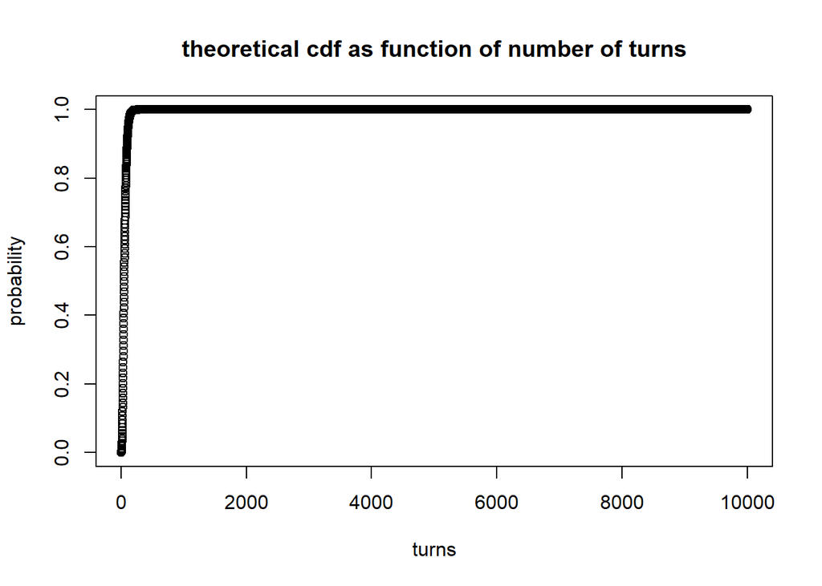

```r
sample_words <- sample(wordling,100)
n_mc <- rep(0,100) # in monte carlo method
for (i in 1:100){
  n_mc[i] <- a6(sample_words[i], p = F)[[1]]
}
p <- 1 / 26
p_dt <- rep(0,10000) # probability deterministic
cdf_dt <- rep(0,10000)
cdf_p <- 0
for (n in 1:10000){
  p1 <- 0
  for (i in 1:5)
  {p1 <- p1 + choose(5,i)*(1-p)^(n*i)*(p^i)*(1-(1-p)^n)^(5-i)}
  p_dt[n] <- p1
  cdf_p <- cdf_p + p1
  cdf_dt[n] <- cdf_p
}

expectaion_sim <- mean(cdf_dt) # calculate empirical expectation
expectaion_teo<- mean(n_mc)

plot(1:10000, cdf_dt,main = "theoretical cdf as function of number of turns",ylab = "probability",
     xlab = "turns"  )
```

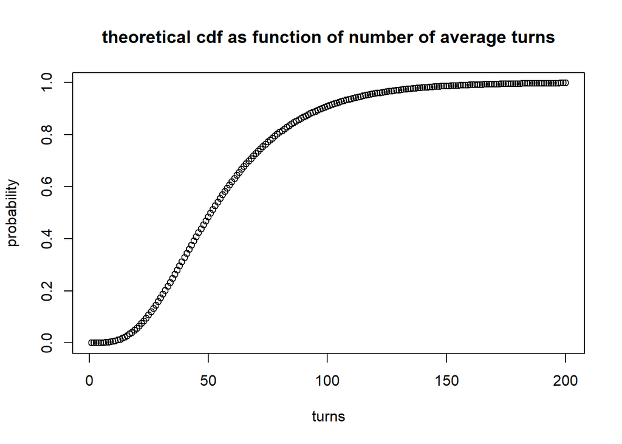

```r
plot(1:200, cdf_dt[1:200],main = "theoretical cdf as function of number of average turns",ylab ="probability",xlab = "turns")
```

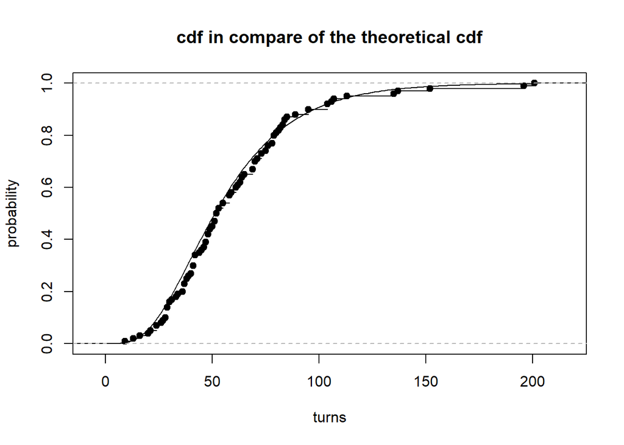

```r
plot(ecdf(n_mc),main = "cdf in compare of the theoretical cdf",ylab ="probability",
     xlab = "turns")
lines(1:200, cdf_dt[1:200], type = "l")
```

7.a. Implement the following two additional strategies for guessing the word:

**Strategy 2:** - At each stage, we guess the word with the highest likelihood (see Qu. 4.c.), **of the remaining words that are consistent with the previous guesses**. - We keep guessing until obtaining the correct word.

```r
st2 <- function(words , word_true){ # a function designed to imlement the strategy from the question.
  guess <- table_prob(b4(words,F),words)[1] # take the most MLE
  times <- 1
  guesses <- c(guess)
  response <- match_words(guess, word_true)
  mat_st2 <- matrix(response, nrow = 1) # add to game's response matrix
    while(!all(response == c(1,1,1,1,1))) {
      if (is.null(guess)){ return('invalid word')} # check whether there's possible words
      words <- b5(guesses,mat_st2,words) # consistant
      guess <- table_prob(b4(words,F),words)[1] # take the most MLE
      response <- match_words(guess, word_true)
      mat_st2 <- rbind(mat_st2,response) # add to game's response matrix
      guesses <- append(guesses, guess)
      times <- times + 1
}
  output <- list(times, guesses)
  return(output)
}
st2( words = wordling,word_true ="vizor")
```

```
## [[1]]
## [1] 4
##
## [[2]]
## [1] "sores" "croon" "razor" "vizor"
```

**Strategy 3:** The same as strategy 2, but at each stage we guess a random word sampled uniformly from all remaining consistent words (instead of guessing the word with the highest likelihood).

Run both strategies with the unknown word “mouse”, and show the guesses and the number of turns for them, in similar to Qu. 6.a.

```r
st3 <- function(words , word_true){ # a function designed to implement the strategy from the question.
  guess <- sample(words,1) # take random
  times <- 1
  guesses <- c(guess)
  response <- match_words(guess, word_true)
  mat_st2 <- matrix(response, nrow = 1) # add to game's response matrix
    while(!all(response == c(1,1,1,1,1))) {
      if (is.null(guess)){ return('invalid word')} # check whether there's possible words
      words <- b5(guesses,mat_st2,words) # consistant
      guess <- sample(words,1) # take random
      response <- match_words(guess, word_true)
      mat_st2 <- rbind(mat_st2,response) # add to game's response matrix
      guesses <- append(guesses, guess)
      times <- times + 1
}
  output <- list(times, guesses)
  return(output)
}
st3( words = wordling,word_true ="mouse")
```

```
## [[1]]
## [1] 5
##
## [[2]]
## [1] "phone" "bogie" "dowse" "louse" "mouse"
```

```r
st2( words = wordling,word_true ="mouse")
```

```
## [[1]]
## [1] 4
##
## [[2]]
## [1] "sores" "douse" "house" "mouse"
```

2. Run $B = 100$ simulations of the games, in similar to Qu. 6.c. That is, each time, sample a random unknown word, run the two strategies $2$ and $3$, and record the number of turns needed to solve `wordle` for both of them.

```r
n_st2 <- rep(0,100)
n_st3 <- rep(0,100)
sample_words <- sample(wordling,100)
sample_words
```

```
##   [1] "elude" "cushy" "capes" "pylon" "kinds" "gimme" "rates" "pitch" "gloss"
##  [10] "world" "taper" "kapok" "prate" "prams" "utero" "atlas" "clock" "cadet"
##  [19] "eerie" "spunk" "batch" "rumor" "veeps" "lulls" "mined" "halls" "orals"
##  [28] "krona" "slice" "vomit" "swipe" "saran" "coqui" "unmap" "units" "plead"
##  [37] "truce" "leeks" "boost" "lasts" "petri" "droid" "tangs" "swims" "frier"
##  [46] "birds" "grain" "ovule" "kilns" "haute" "adapt" "slept" "boils" "clerk"
##  [55] "sedan" "timer" "mrads" "spays" "boast" "plant" "clunk" "flume" "amble"
##  [64] "telex" "rouge" "buret" "sandy" "pears" "ritzy" "realm" "hires" "dryad"
##  [73] "filly" "golem" "rondo" "harem" "peals" "parse" "turns" "limes" "dippy"
##  [82] "media" "mitre" "spics" "veins" "somas" "wager" "costs" "reuse" "firer"
##  [91] "twixt" "jacks" "squad" "gazer" "crazy" "doggy" "groks" "middy" "quart"
## [100] "crash"
```

[figure not shown]

```r
for (i in 1:100){ # use the loop to acticate the strategies on n_st2 and n_st3.
  n_st3[i] <- st3(words = wordling,word_true = sample_words[i])[[1]]
  n_st2[i] <- st2(words = wordling,word_true = sample_words[i])[[1]]
}
plot(ecdf(n_st3),col='blue',main = "cdf for strategies 2,3:",ylab = "probability",xlab="number of turns")
lines(ecdf(n_st2),col = 'red')
legend("topleft",legend=c("Strategy 3", "Strategy 3"),
       col=c("blue", "red"), lty=1:2, cex=0.8)
```

```r
expectaion_3 <- mean(n_st3) # calculate empirical expectation
expectaion_2<- mean(n_st2)
```

- Plot the empirical CDFs of the number of guesses. How similar are they to each other? how similar are they to the CDF of strategy 1? What are the empirical means for both strategies?
3. (Bonus**) Can you design a better guessing strategy? Design and implement a different guessing strategy, run it on $B=100$ random simulations, show the empirical CDF and compute the empirical mean. Your strategy is considered `better` if it shows a significant reduction in the mean number of turns compared to the previous strategies (you should think how to show that the difference is significant)

[figure not shown]

```r
st4 <- function(words , word_true){ # a function designed to imlement the strategy from the question.
  guess <- 'audio' # take word with many vowels
  times <- 1
  guesses <- c(guess)
  response <- match_words(guess, word_true)
  mat_st2 <- matrix(response, nrow = 1) # add to game's response matrix
    while(!all(response == c(1,1,1,1,1))) {
      if (is.null(guess)){ return('invalid word')} # check whether there's possible words
      words <- b5(guesses,mat_st2,words) # consistant
      guess <- table_prob(b4(words,F),words)[1] # take the most MLE
      response <- match_words(guess, word_true)
      mat_st2 <- rbind(mat_st2,response) # add to game's response matrix
      guesses <- append(guesses, guess)
      times <- times + 1
}
  output <- list(times, guesses)
  return(output)
}
n_st4 <- rep(0,100)
sample_words <- sample(wordling,100)
for (i in 1:100){ # use the loop to acticate the strategies on n_st2 and n_st3.
  n_st4[i] <- st4(words = wordling,word_true = sample_words[i])[[1]]
}


plot(ecdf(n_st3),col='blue', main = "cdf for strategies 2,3:",ylab = "probability",xlab="number of turns")
lines(ecdf(n_st4),col = 'red')
legend(2, 4, legend=c("Strategy 3", "Strategy 3"),
       col=c("blue", "red"), lty=1:2, cex=0.8)
```

```r
expectaion_4 <- mean(n_st4) # calculate empirical expectation
expectaion_4
```

```
## [1] 4.85
```